# Notebook

```
                              Assignment 3: Convolution
```

Author: Olayinka Hammed Sikiru

Downloading the data

```python
# Installing gdown
!pip install -U gdown

# Setting up the Google Drive file URL
file_id = '1L-kq2QQDrQrwl0PCgiP3Vkay0GdWGfi5'
gdown_url = f"https://drive.google.com/uc?id={file_id}"

# Downloading the file using gdown
!gdown {gdown_url}

# Unzipping the dataset (assuming the file is downloaded as 'dogs-vs-cats.zip')
import zipfile

with zipfile.ZipFile('dogs-vs-cats.zip', 'r') as zip_ref:
    zip_ref.extractall('/content/dogs-vs-cats')

# Checking the extracted contents
import os
extracted_dir = '/content/dogs-vs-cats'
print(os.listdir(extracted_dir))
```

```
Downloading...
From (original): https://drive.google.com/uc?id=1L-kq2QQDrQrwl0PCgiP3Vkay0GdWGfi5
From (redirected): https://drive.google.com/uc?id=1L-kq2QQDrQrwl0PCgiP3Vkay0GdWGfi5&confirm=t&uuid=946c901c-5ea1-4b54-93dd-b2f6864d7f56
To: /content/dogs-vs-cats.zip
100% 852M/852M [00:19<00:00, 43.3MB/s]
['train.zip', 'test1.zip', 'sampleSubmission.csv']
```

```python
# Unzipping the 'dogs-vs-cats.zip' file
!unzip -qq dogs-vs-cats.zip

# Unzipping the 'train.zip' file
!unzip -qq train.zip
```

```python
import zipfile
import os

# Define paths for the zip files
dataset_dir = '/content/dogs-vs-cats'
train_zip_path = os.path.join(dataset_dir, 'train.zip')
test_zip_path = os.path.join(dataset_dir, 'test1.zip')

# Extract train.zip and test1.zip to the base directory
with zipfile.ZipFile(train_zip_path, 'r') as zip_ref:
    zip_ref.extractall(dataset_dir)

with zipfile.ZipFile(test_zip_path, 'r') as zip_ref:
    zip_ref.extractall(dataset_dir)

# Check the structure of the base directory after extraction
print("Contents of dataset directory after extraction:", os.listdir(dataset_dir))
```

```
Contents of dataset directory after extraction: ['train', 'train.zip', 'test1.zip', 'sampleSubmission.csv', 'test1']
```

```python
# Define the paths to the extracted train and test folders
train_dir = '/content/dogs-vs-cats/train'
test_dir = '/content/dogs-vs-cats/test1'

# Count images in train and test directories
num_train_images = len(os.listdir(train_dir))
num_test_images = len(os.listdir(test_dir))

print(f"Number of images in the training set: {num_train_images}")
print(f"Number of images in the test set: {num_test_images}")

# Total count of images
total_images = num_train_images + num_test_images
print(f"Total number of images in the dataset: {total_images}")
```

```
Number of images in the training set: 25000
Number of images in the test set: 12500
Total number of images in the dataset: 37500
```

**1. Consider the Cats & Dogs example. Start initially with a training sample of 1000, a validation sample of 500, and a test sample of 500 (half the sample size as the sample Jupyter notebook on Canvas). Use any technique to reduce overfitting and improve performance in developing a network that you train from scratch. What performance did you achieve?**

Data Processing for Training, Validation, and Testing Subsets

```python
import os, shutil, pathlib

# Defining directory of folder to store subsets of our originial data
original_dir = pathlib.Path("train")
new_base_dir = pathlib.Path("cats_vs_dogs")

# Defining a function to make subsets
def make_subset(subset_name, start_index, end_index):
    for category in ("cat", "dog"):
        dir = new_base_dir / subset_name / category
        os.makedirs(dir, exist_ok=True)  # Allow existing directories
        fnames = [f"{category}.{i}.jpg" for i in range(start_index, end_index)]
        for fname in fnames:
            shutil.copyfile(src=original_dir / fname,
                            dst=dir / fname)

# Taking 1000 samples in training set
make_subset("train", start_index=0, end_index=1000)
# Taking 500 samples in validaton set
make_subset("validation", start_index=1000, end_index=1500)
# Taking 500 samples in test set
make_subset("test", start_index=1500, end_index=2000)
```

```python
from tensorflow.keras.utils import image_dataset_from_directory
import numpy as np
import tensorflow as tf

# Reading training, validation and testing datsets
train_dataset = image_dataset_from_directory(
    new_base_dir / "train",
    image_size=(180, 180),
    batch_size=32)
validation_dataset = image_dataset_from_directory(
    new_base_dir / "validation",
    image_size=(180, 180),
    batch_size=32)
test_dataset = image_dataset_from_directory(
    new_base_dir / "test",
    image_size=(180, 180),
    batch_size=32)
print("Data Subsets Created Successfully!\n")
```

```
Found 2000 files belonging to 2 classes.
Found 1000 files belonging to 2 classes.
Found 1000 files belonging to 2 classes.
Data Subsets Created Successfully!
```

```python
import numpy as np
import tensorflow as tf
# Working with random numbers dataset
print("Working with Random Numbers Dataset")

random_numbers = np.random.normal(size=(1000, 16))
dataset = tf.data.Dataset.from_tensor_slices(random_numbers)

# Display shape of each element
for i, element in enumerate(dataset):
    print("Element shape:", element.shape)
    if i >= 2:
        break
```

```
Working with Random Numbers Dataset
Element shape: (16,)
Element shape: (16,)
Element shape: (16,)
```

```python
# Batching the dataset
print("\n Batching the Dataset")

batched_dataset = dataset.batch(32)
for i, element in enumerate(batched_dataset):
    print("Batched element shape:", element.shape)
    if i >= 2:
        break
```

```
 Batching the Dataset
Batched element shape: (32, 16)
Batched element shape: (32, 16)
Batched element shape: (32, 16)
```

```python
# Reshaping each element in the dataset
print("\n Reshaping Each Element to (4, 4)")

reshaped_dataset = dataset.map(lambda x: tf.reshape(x, (4, 4)))
for i, element in enumerate(reshaped_dataset):
    print("Reshaped element shape:", element.shape)
    if i >= 2:
        break
```

```
 Reshaping Each Element to (4, 4)
Reshaped element shape: (4, 4)
Reshaped element shape: (4, 4)
Reshaped element shape: (4, 4)
```

```python
# Displaying batch shapes from train dataset
print("\n Displaying Batch Shapes from Train Dataset")

for data_batch, labels_batch in train_dataset:
    print("Data batch shape:", data_batch.shape)
    print("Labels batch shape:", labels_batch.shape)
    break
```

```
 Displaying Batch Shapes from Train Dataset
Data batch shape: (32, 180, 180, 3)
Labels batch shape: (32,)
```

```python
# Importing keras and layers
from tensorflow import keras
from tensorflow.keras import layers
import matplotlib.pyplot as plt
```

```python
#  Constructing the model
inputs = keras.Input(shape=(180, 180, 3))
x = layers.Rescaling(1./255)(inputs)
x = layers.Conv2D(filters=32, kernel_size=3, activation="relu")(x)
x = layers.MaxPooling2D(pool_size=2)(x)
x = layers.Conv2D(filters=64, kernel_size=3, activation="relu")(x)
x = layers.MaxPooling2D(pool_size=2)(x)
x = layers.Conv2D(filters=128, kernel_size=3, activation="relu")(x)
x = layers.MaxPooling2D(pool_size=2)(x)
x = layers.Conv2D(filters=256, kernel_size=3, activation="relu")(x)
x = layers.MaxPooling2D(pool_size=2)(x)
x = layers.Conv2D(filters=256, kernel_size=3, activation="relu")(x)
x = layers.Flatten()(x)
outputs = layers.Dense(1, activation="sigmoid")(x)
model = keras.Model(inputs=inputs, outputs=outputs)
```

Examining the model

```python
model.summary()
```

```
Model: "functional"
```

```
┏━━━━━━━━━━━━━━━━━━━━━━━━━━━━━━━━━━━━━━┳━━━━━━━━━━━━━━━━━━━━━━━━━━━━━┳━━━━━━━━━━━━━━━━━┓
┃ Layer (type)                         ┃ Output Shape                ┃         Param # ┃
┡━━━━━━━━━━━━━━━━━━━━━━━━━━━━━━━━━━━━━━╇━━━━━━━━━━━━━━━━━━━━━━━━━━━━━╇━━━━━━━━━━━━━━━━━┩
│ input_layer (InputLayer)             │ (None, 180, 180, 3)         │               0 │
├──────────────────────────────────────┼─────────────────────────────┼─────────────────┤
│ rescaling (Rescaling)                │ (None, 180, 180, 3)         │               0 │
├──────────────────────────────────────┼─────────────────────────────┼─────────────────┤
│ conv2d (Conv2D)                      │ (None, 178, 178, 32)        │             896 │
├──────────────────────────────────────┼─────────────────────────────┼─────────────────┤
│ max_pooling2d (MaxPooling2D)         │ (None, 89, 89, 32)          │               0 │
├──────────────────────────────────────┼─────────────────────────────┼─────────────────┤
│ conv2d_1 (Conv2D)                    │ (None, 87, 87, 64)          │          18,496 │
├──────────────────────────────────────┼─────────────────────────────┼─────────────────┤
│ max_pooling2d_1 (MaxPooling2D)       │ (None, 43, 43, 64)          │               0 │
├──────────────────────────────────────┼─────────────────────────────┼─────────────────┤
│ conv2d_2 (Conv2D)                    │ (None, 41, 41, 128)         │          73,856 │
├──────────────────────────────────────┼─────────────────────────────┼─────────────────┤
│ max_pooling2d_2 (MaxPooling2D)       │ (None, 20, 20, 128)         │               0 │
├──────────────────────────────────────┼─────────────────────────────┼─────────────────┤
│ conv2d_3 (Conv2D)                    │ (None, 18, 18, 256)         │         295,168 │
├──────────────────────────────────────┼─────────────────────────────┼─────────────────┤
│ max_pooling2d_3 (MaxPooling2D)       │ (None, 9, 9, 256)           │               0 │
├──────────────────────────────────────┼─────────────────────────────┼─────────────────┤
│ conv2d_4 (Conv2D)                    │ (None, 7, 7, 256)           │         590,080 │
├──────────────────────────────────────┼─────────────────────────────┼─────────────────┤
│ flatten (Flatten)                    │ (None, 12544)               │               0 │
├──────────────────────────────────────┼─────────────────────────────┼─────────────────┤
│ dense (Dense)                        │ (None, 1)                   │          12,545 │
└──────────────────────────────────────┴─────────────────────────────┴─────────────────┘
```

```
 Total params: 991,041 (3.78 MB)
```

```
 Trainable params: 991,041 (3.78 MB)
```

```
 Non-trainable params: 0 (0.00 B)
```

Compiling the model with specified configurations

```python
model.compile(loss="binary_crossentropy",
              optimizer="Adam",
              metrics=["accuracy"])
```

Training the model on the training and validation datasets

```python
training = model.fit(train_dataset,
                    epochs = 30,
                    validation_data = validation_dataset)
```

```
63/63 ━━━━━━━━━━━━━━━━━━━━ 25s 266ms/step - accuracy: 0.5076 - loss: 0.6981 - val_accuracy: 0.5360 - val_loss: 0.6824
63/63 ━━━━━━━━━━━━━━━━━━━━ 4s 61ms/step - accuracy: 0.5749 - loss: 0.6683 - val_accuracy: 0.6210 - val_loss: 0.6774
63/63 ━━━━━━━━━━━━━━━━━━━━ 5s 57ms/step - accuracy: 0.5747 - loss: 0.6595 - val_accuracy: 0.5000 - val_loss: 1.6658
63/63 ━━━━━━━━━━━━━━━━━━━━ 8s 107ms/step - accuracy: 0.6003 - loss: 0.7678 - val_accuracy: 0.6610 - val_loss: 0.6422
63/63 ━━━━━━━━━━━━━━━━━━━━ 7s 57ms/step - accuracy: 0.6458 - loss: 0.6334 - val_accuracy: 0.6550 - val_loss: 0.6059
63/63 ━━━━━━━━━━━━━━━━━━━━ 4s 68ms/step - accuracy: 0.6771 - loss: 0.5959 - val_accuracy: 0.6720 - val_loss: 0.5970
63/63 ━━━━━━━━━━━━━━━━━━━━ 6s 76ms/step - accuracy: 0.7084 - loss: 0.5682 - val_accuracy: 0.6650 - val_loss: 0.6231
63/63 ━━━━━━━━━━━━━━━━━━━━ 4s 56ms/step - accuracy: 0.7417 - loss: 0.5237 - val_accuracy: 0.7180 - val_loss: 0.5653
63/63 ━━━━━━━━━━━━━━━━━━━━ 7s 82ms/step - accuracy: 0.7544 - loss: 0.4763 - val_accuracy: 0.6720 - val_loss: 0.6850
63/63 ━━━━━━━━━━━━━━━━━━━━ 5s 80ms/step - accuracy: 0.7810 - loss: 0.4393 - val_accuracy: 0.7010 - val_loss: 0.6110
63/63 ━━━━━━━━━━━━━━━━━━━━ 4s 57ms/step - accuracy: 0.8227 - loss: 0.3809 - val_accuracy: 0.7350 - val_loss: 0.5683
63/63 ━━━━━━━━━━━━━━━━━━━━ 7s 81ms/step - accuracy: 0.8721 - loss: 0.3095 - val_accuracy: 0.7230 - val_loss: 0.6418
63/63 ━━━━━━━━━━━━━━━━━━━━ 5s 77ms/step - accuracy: 0.9221 - loss: 0.2059 - val_accuracy: 0.7460 - val_loss: 0.6958
63/63 ━━━━━━━━━━━━━━━━━━━━ 4s 60ms/step - accuracy: 0.9271 - loss: 0.1847 - val_accuracy: 0.7480 - val_loss: 0.7876
63/63 ━━━━━━━━━━━━━━━━━━━━ 4s 57ms/step - accuracy: 0.9631 - loss: 0.0964 - val_accuracy: 0.7100 - val_loss: 0.9760
63/63 ━━━━━━━━━━━━━━━━━━━━ 7s 105ms/step - accuracy: 0.9588 - loss: 0.1076 - val_accuracy: 0.7370 - val_loss: 0.9944
63/63 ━━━━━━━━━━━━━━━━━━━━ 4s 56ms/step - accuracy: 0.9528 - loss: 0.1225 - val_accuracy: 0.7390 - val_loss: 0.9714
63/63 ━━━━━━━━━━━━━━━━━━━━ 5s 60ms/step - accuracy: 0.9833 - loss: 0.0428 - val_accuracy: 0.7300 - val_loss: 1.2045
63/63 ━━━━━━━━━━━━━━━━━━━━ 8s 108ms/step - accuracy: 0.9949 - loss: 0.0294 - val_accuracy: 0.7320 - val_loss: 1.3770
63/63 ━━━━━━━━━━━━━━━━━━━━ 7s 56ms/step - accuracy: 0.9957 - loss: 0.0165 - val_accuracy: 0.7360 - val_loss: 1.5032
63/63 ━━━━━━━━━━━━━━━━━━━━ 7s 89ms/step - accuracy: 0.9905 - loss: 0.0279 - val_accuracy: 0.7360 - val_loss: 1.4532
63/63 ━━━━━━━━━━━━━━━━━━━━ 4s 65ms/step - accuracy: 0.9925 - loss: 0.0299 - val_accuracy: 0.7250 - val_loss: 1.5606
63/63 ━━━━━━━━━━━━━━━━━━━━ 4s 57ms/step - accuracy: 0.9969 - loss: 0.0175 - val_accuracy: 0.7550 - val_loss: 1.5501
63/63 ━━━━━━━━━━━━━━━━━━━━ 7s 85ms/step - accuracy: 1.0000 - loss: 0.0028 - val_accuracy: 0.7540 - val_loss: 1.6713
63/63 ━━━━━━━━━━━━━━━━━━━━ 5s 76ms/step - accuracy: 1.0000 - loss: 6.5850e-04 - val_accuracy: 0.7570 - val_loss: 1.7374
63/63 ━━━━━━━━━━━━━━━━━━━━ 4s 60ms/step - accuracy: 1.0000 - loss: 3.7336e-04 - val_accuracy: 0.7620 - val_loss: 1.7833
63/63 ━━━━━━━━━━━━━━━━━━━━ 4s 61ms/step - accuracy: 1.0000 - loss: 2.9571e-04 - val_accuracy: 0.7590 - val_loss: 1.8282
63/63 ━━━━━━━━━━━━━━━━━━━━ 7s 88ms/step - accuracy: 1.0000 - loss: 2.2907e-04 - val_accuracy: 0.7610 - val_loss: 1.8740
63/63 ━━━━━━━━━━━━━━━━━━━━ 4s 57ms/step - accuracy: 1.0000 - loss: 1.7464e-04 - val_accuracy: 0.7620 - val_loss: 1.9298
63/63 ━━━━━━━━━━━━━━━━━━━━ 6s 64ms/step - accuracy: 1.0000 - loss: 1.4054e-04 - val_accuracy: 0.7590 - val_loss: 1.9899
```

Next, we’ll plot the training and validation loss and accuracy to assess any signs of overfitting.

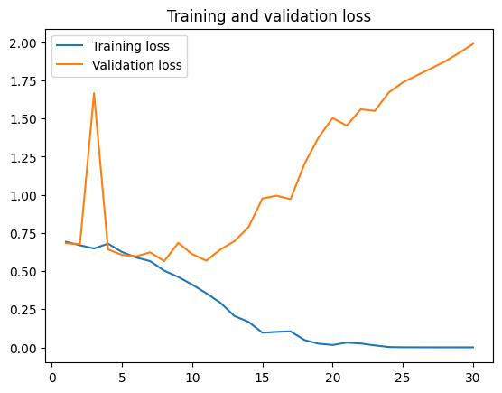

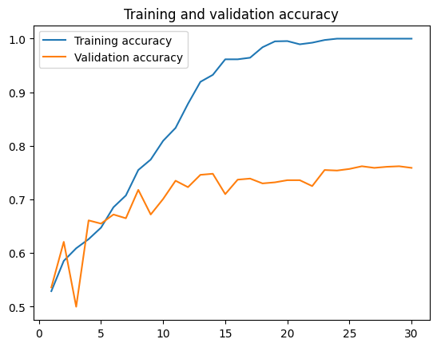

```python
# Storing accuracies and losses in variables
accuracy = training.history["accuracy"]
val_accuracy = training.history["val_accuracy"]
loss = training.history["loss"]
val_loss = training.history["val_loss"]
epochs = range(1, len(accuracy) + 1)
# Plotting losses
plt.plot(epochs, loss, label="Training loss")
plt.plot(epochs, val_loss, label="Validation loss")
plt.title("Training and validation loss")
plt.legend()
plt.figure()
# Plotting accuracies
plt.plot(epochs, accuracy, label="Training accuracy")
plt.plot(epochs, val_accuracy, label="Validation accuracy")
plt.title("Training and validation accuracy")
plt.legend()
```

These graphs indicate overfitting, so we'll need to apply techniques to address it. Next, let's check the accuracy on the test data, which we expect to be low due to the overfitting.

```python
model.evaluate(test_dataset)
```

```
32/32 ━━━━━━━━━━━━━━━━━━━━ 2s 58ms/step - accuracy: 0.7218 - loss: 2.3097
```

```
[2.344470977783203, 0.7210000157356262]
```

As a result, the accuracy was **72.1%**, which is quite low.

Using data augmentation and dropout to reduce overfitting

```python
# Using keras sequential for data augmentation
data_augmentation = keras.Sequential(
    [
        layers.RandomFlip("horizontal"),
        layers.RandomRotation(0.1),
        layers.RandomZoom(0.1),
    ])
```

Trying to print photos to have a look at data augmentation:

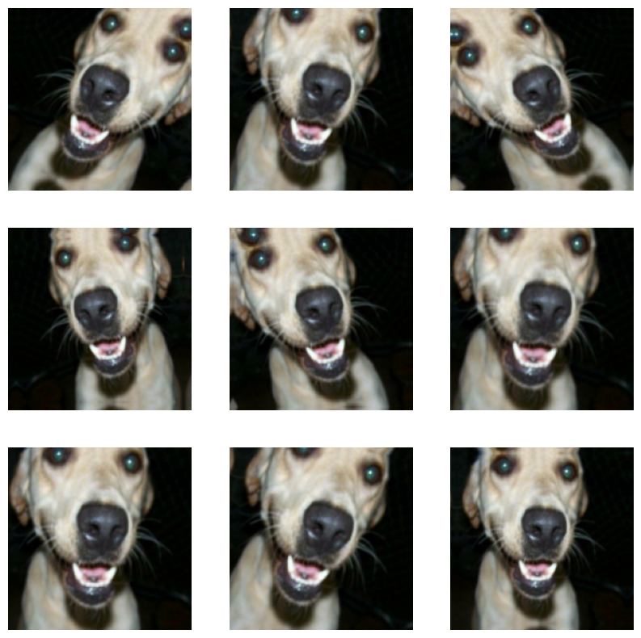

```python
import numpy
plt.figure(figsize=(10, 10))
for images, _ in train_dataset.take(1):
    for i in range(9):
        augmented_images = data_augmentation(images)
        ax = plt.subplot(3, 3, i + 1)
        plt.imshow(augmented_images[0].numpy().astype("uint8"))
        plt.axis("off")
```

Constructing model again with Data Augmentation and Dropout

```python
inputs = keras.Input(shape = (180,180,3))
x=data_augmentation(inputs)
x = layers.Rescaling(1./255)(x)
x = layers.Conv2D(filters = 32, kernel_size = 3, activation = "relu")(x)
x = layers.MaxPooling2D(pool_size=2)(x)
x = layers.Conv2D(filters = 64, kernel_size = 3, activation = "relu")(x)
x = layers.MaxPooling2D(pool_size=2)(x)
x = layers.Conv2D(filters = 128, kernel_size = 3, activation = "relu")(x)
x = layers.MaxPooling2D(pool_size=2)(x)
x = layers.Conv2D(filters = 256, kernel_size = 3, activation = "relu")(x)
x = layers.MaxPooling2D(pool_size=2)(x)
x = layers.Conv2D(filters = 256, kernel_size = 3, activation = "relu")(x)
x = layers.Flatten()(x)
x= layers.Dropout(0.5)(x)
outputs = layers.Dense(1,activation = "sigmoid")(x)
model = keras.Model(inputs = inputs, outputs = outputs)

# Compiling model
model.compile(loss = "binary_crossentropy",
             optimizer= "Adam",
             metrics = ["accuracy"])
model.summary()
```

```
Model: "functional_2"
```

```
┏━━━━━━━━━━━━━━━━━━━━━━━━━━━━━━━━━━━━━━┳━━━━━━━━━━━━━━━━━━━━━━━━━━━━━┳━━━━━━━━━━━━━━━━━┓
┃ Layer (type)                         ┃ Output Shape                ┃         Param # ┃
┡━━━━━━━━━━━━━━━━━━━━━━━━━━━━━━━━━━━━━━╇━━━━━━━━━━━━━━━━━━━━━━━━━━━━━╇━━━━━━━━━━━━━━━━━┩
│ input_layer_2 (InputLayer)           │ (None, 180, 180, 3)         │               0 │
├──────────────────────────────────────┼─────────────────────────────┼─────────────────┤
│ sequential (Sequential)              │ (None, 180, 180, 3)         │               0 │
├──────────────────────────────────────┼─────────────────────────────┼─────────────────┤
│ rescaling_1 (Rescaling)              │ (None, 180, 180, 3)         │               0 │
├──────────────────────────────────────┼─────────────────────────────┼─────────────────┤
│ conv2d_5 (Conv2D)                    │ (None, 178, 178, 32)        │             896 │
├──────────────────────────────────────┼─────────────────────────────┼─────────────────┤
│ max_pooling2d_4 (MaxPooling2D)       │ (None, 89, 89, 32)          │               0 │
├──────────────────────────────────────┼─────────────────────────────┼─────────────────┤
│ conv2d_6 (Conv2D)                    │ (None, 87, 87, 64)          │          18,496 │
├──────────────────────────────────────┼─────────────────────────────┼─────────────────┤
│ max_pooling2d_5 (MaxPooling2D)       │ (None, 43, 43, 64)          │               0 │
├──────────────────────────────────────┼─────────────────────────────┼─────────────────┤
│ conv2d_7 (Conv2D)                    │ (None, 41, 41, 128)         │          73,856 │
├──────────────────────────────────────┼─────────────────────────────┼─────────────────┤
│ max_pooling2d_6 (MaxPooling2D)       │ (None, 20, 20, 128)         │               0 │
├──────────────────────────────────────┼─────────────────────────────┼─────────────────┤
│ conv2d_8 (Conv2D)                    │ (None, 18, 18, 256)         │         295,168 │
├──────────────────────────────────────┼─────────────────────────────┼─────────────────┤
│ max_pooling2d_7 (MaxPooling2D)       │ (None, 9, 9, 256)           │               0 │
├──────────────────────────────────────┼─────────────────────────────┼─────────────────┤
│ conv2d_9 (Conv2D)                    │ (None, 7, 7, 256)           │         590,080 │
├──────────────────────────────────────┼─────────────────────────────┼─────────────────┤
│ flatten_1 (Flatten)                  │ (None, 12544)               │               0 │
├──────────────────────────────────────┼─────────────────────────────┼─────────────────┤
│ dropout (Dropout)                    │ (None, 12544)               │               0 │
├──────────────────────────────────────┼─────────────────────────────┼─────────────────┤
│ dense_1 (Dense)                      │ (None, 1)                   │          12,545 │
└──────────────────────────────────────┴─────────────────────────────┴─────────────────┘
```

```
 Total params: 991,041 (3.78 MB)
```

```
 Trainable params: 991,041 (3.78 MB)
```

```
 Non-trainable params: 0 (0.00 B)
```

```python
# Fitting this new model :
training = model.fit(train_dataset,
                    epochs = 60,
                    validation_data = validation_dataset)
```

```
63/63 ━━━━━━━━━━━━━━━━━━━━ 13s 124ms/step - accuracy: 0.5087 - loss: 0.7130 - val_accuracy: 0.5000 - val_loss: 0.6890
63/63 ━━━━━━━━━━━━━━━━━━━━ 17s 116ms/step - accuracy: 0.5502 - loss: 0.6872 - val_accuracy: 0.5300 - val_loss: 0.7028
63/63 ━━━━━━━━━━━━━━━━━━━━ 4s 65ms/step - accuracy: 0.6143 - loss: 0.6675 - val_accuracy: 0.6430 - val_loss: 0.6332
63/63 ━━━━━━━━━━━━━━━━━━━━ 4s 60ms/step - accuracy: 0.6702 - loss: 0.6313 - val_accuracy: 0.6380 - val_loss: 0.6301
63/63 ━━━━━━━━━━━━━━━━━━━━ 6s 102ms/step - accuracy: 0.6718 - loss: 0.6025 - val_accuracy: 0.6570 - val_loss: 0.6267
63/63 ━━━━━━━━━━━━━━━━━━━━ 4s 66ms/step - accuracy: 0.6900 - loss: 0.5930 - val_accuracy: 0.6800 - val_loss: 0.6096
63/63 ━━━━━━━━━━━━━━━━━━━━ 4s 64ms/step - accuracy: 0.6888 - loss: 0.5966 - val_accuracy: 0.6780 - val_loss: 0.6030
63/63 ━━━━━━━━━━━━━━━━━━━━ 5s 78ms/step - accuracy: 0.7261 - loss: 0.5681 - val_accuracy: 0.6810 - val_loss: 0.5891
63/63 ━━━━━━━━━━━━━━━━━━━━ 5s 81ms/step - accuracy: 0.7160 - loss: 0.5460 - val_accuracy: 0.6720 - val_loss: 0.5817
63/63 ━━━━━━━━━━━━━━━━━━━━ 10s 85ms/step - accuracy: 0.7278 - loss: 0.5449 - val_accuracy: 0.7200 - val_loss: 0.5303
63/63 ━━━━━━━━━━━━━━━━━━━━ 9s 64ms/step - accuracy: 0.7387 - loss: 0.5332 - val_accuracy: 0.6850 - val_loss: 0.5797
63/63 ━━━━━━━━━━━━━━━━━━━━ 5s 86ms/step - accuracy: 0.7428 - loss: 0.5313 - val_accuracy: 0.7120 - val_loss: 0.5579
63/63 ━━━━━━━━━━━━━━━━━━━━ 9s 65ms/step - accuracy: 0.7080 - loss: 0.5359 - val_accuracy: 0.7340 - val_loss: 0.5445
63/63 ━━━━━━━━━━━━━━━━━━━━ 6s 78ms/step - accuracy: 0.7568 - loss: 0.5085 - val_accuracy: 0.7350 - val_loss: 0.5411
63/63 ━━━━━━━━━━━━━━━━━━━━ 6s 88ms/step - accuracy: 0.7481 - loss: 0.5153 - val_accuracy: 0.7320 - val_loss: 0.5372
63/63 ━━━━━━━━━━━━━━━━━━━━ 9s 65ms/step - accuracy: 0.7655 - loss: 0.4869 - val_accuracy: 0.7620 - val_loss: 0.4841
63/63 ━━━━━━━━━━━━━━━━━━━━ 6s 98ms/step - accuracy: 0.7714 - loss: 0.4577 - val_accuracy: 0.7340 - val_loss: 0.5473
63/63 ━━━━━━━━━━━━━━━━━━━━ 8s 65ms/step - accuracy: 0.7560 - loss: 0.4793 - val_accuracy: 0.7600 - val_loss: 0.4956
63/63 ━━━━━━━━━━━━━━━━━━━━ 8s 104ms/step - accuracy: 0.8045 - loss: 0.4248 - val_accuracy: 0.7610 - val_loss: 0.4954
63/63 ━━━━━━━━━━━━━━━━━━━━ 7s 59ms/step - accuracy: 0.7861 - loss: 0.4599 - val_accuracy: 0.7660 - val_loss: 0.5109
63/63 ━━━━━━━━━━━━━━━━━━━━ 4s 71ms/step - accuracy: 0.8075 - loss: 0.4341 - val_accuracy: 0.7680 - val_loss: 0.4963
63/63 ━━━━━━━━━━━━━━━━━━━━ 6s 93ms/step - accuracy: 0.8041 - loss: 0.4272 - val_accuracy: 0.7520 - val_loss: 0.5115
63/63 ━━━━━━━━━━━━━━━━━━━━ 4s 59ms/step - accuracy: 0.8204 - loss: 0.3833 - val_accuracy: 0.7730 - val_loss: 0.4611
63/63 ━━━━━━━━━━━━━━━━━━━━ 5s 64ms/step - accuracy: 0.8277 - loss: 0.3968 - val_accuracy: 0.7870 - val_loss: 0.4547
63/63 ━━━━━━━━━━━━━━━━━━━━ 6s 97ms/step - accuracy: 0.8356 - loss: 0.3861 - val_accuracy: 0.7860 - val_loss: 0.4844
63/63 ━━━━━━━━━━━━━━━━━━━━ 8s 64ms/step - accuracy: 0.8272 - loss: 0.3812 - val_accuracy: 0.7660 - val_loss: 0.5013
63/63 ━━━━━━━━━━━━━━━━━━━━ 7s 100ms/step - accuracy: 0.8247 - loss: 0.4020 - val_accuracy: 0.7960 - val_loss: 0.4450
63/63 ━━━━━━━━━━━━━━━━━━━━ 4s 66ms/step - accuracy: 0.8323 - loss: 0.3539 - val_accuracy: 0.7600 - val_loss: 0.5812
63/63 ━━━━━━━━━━━━━━━━━━━━ 4s 59ms/step - accuracy: 0.8475 - loss: 0.3661 - val_accuracy: 0.7870 - val_loss: 0.4552
63/63 ━━━━━━━━━━━━━━━━━━━━ 4s 66ms/step - accuracy: 0.8667 - loss: 0.3348 - val_accuracy: 0.7940 - val_loss: 0.4291
63/63 ━━━━━━━━━━━━━━━━━━━━ 9s 120ms/step - accuracy: 0.8576 - loss: 0.3353 - val_accuracy: 0.8110 - val_loss: 0.4276
63/63 ━━━━━━━━━━━━━━━━━━━━ 5s 76ms/step - accuracy: 0.8658 - loss: 0.3245 - val_accuracy: 0.8030 - val_loss: 0.4578
63/63 ━━━━━━━━━━━━━━━━━━━━ 6s 92ms/step - accuracy: 0.8610 - loss: 0.3129 - val_accuracy: 0.7610 - val_loss: 0.4929
63/63 ━━━━━━━━━━━━━━━━━━━━ 5s 77ms/step - accuracy: 0.8508 - loss: 0.3283 - val_accuracy: 0.7980 - val_loss: 0.4413
63/63 ━━━━━━━━━━━━━━━━━━━━ 4s 60ms/step - accuracy: 0.8709 - loss: 0.2965 - val_accuracy: 0.7780 - val_loss: 0.5216
63/63 ━━━━━━━━━━━━━━━━━━━━ 4s 68ms/step - accuracy: 0.8527 - loss: 0.3298 - val_accuracy: 0.8010 - val_loss: 0.4515
63/63 ━━━━━━━━━━━━━━━━━━━━ 6s 82ms/step - accuracy: 0.8646 - loss: 0.3246 - val_accuracy: 0.7780 - val_loss: 0.5050
63/63 ━━━━━━━━━━━━━━━━━━━━ 10s 73ms/step - accuracy: 0.8606 - loss: 0.3088 - val_accuracy: 0.8330 - val_loss: 0.4231
63/63 ━━━━━━━━━━━━━━━━━━━━ 6s 91ms/step - accuracy: 0.8972 - loss: 0.2601 - val_accuracy: 0.7890 - val_loss: 0.4903
63/63 ━━━━━━━━━━━━━━━━━━━━ 9s 64ms/step - accuracy: 0.8841 - loss: 0.2939 - val_accuracy: 0.8080 - val_loss: 0.4645
```

[output cut: 20 more lines]

Plotting accuracies and losses

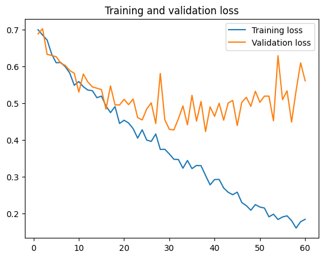

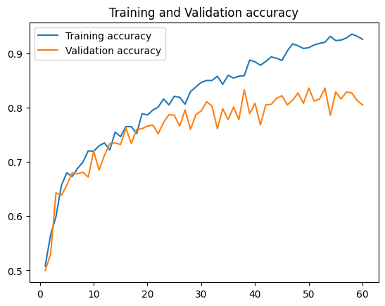

```python
# Storing accuracies and losses in variables
accuracy = training.history["accuracy"]
val_accuracy = training.history["val_accuracy"]
loss = training.history["loss"]
val_loss = training.history["val_loss"]
epochs = range(1,len(accuracy)+1)
# Plotting losses
plt.plot(epochs,loss,label="Training loss")
plt.plot(epochs,val_loss,label="Validation loss")
plt.title("Training and validation loss")
plt.legend()
plt.figure()
# Plotting accuracies
plt.plot(epochs,accuracy,label="Training accuracy")
plt.plot(epochs, val_accuracy,label="Validation accuracy")
plt.title("Training and Validation accuracy")
plt.legend()
```

Testing our model on testing data

```python
model.evaluate(test_dataset)
```

```
32/32 ━━━━━━━━━━━━━━━━━━━━ 2s 55ms/step - accuracy: 0.7982 - loss: 0.5467
```

```
[0.5677192211151123, 0.796999990940094]
```

Our model’s accuracy has now reached **79.7%**, an improvement over the results we achieved without data augmentation and dropout.

**2. Increase your training sample size. You may pick any amount. Keep the validation and test samples the same as above. Optimize your network (again training from scratch). What performance did you achieve?**

Creating subsets with an increased training dataset size (2000), while keeping validation and test sizes unchanged:

```python
make_subset("train_2", start_index=0, end_index=2000)
make_subset("validation_2", start_index=2000, end_index=2500)
make_subset("test_2", start_index=2500, end_index=3000)
```

Creating new training, validation, and test sets

```python
train_dataset = image_dataset_from_directory(
    new_base_dir / "train_2",
    image_size=(180, 180),
    batch_size=32)
validation_dataset = image_dataset_from_directory(
    new_base_dir / "validation_2",
    image_size=(180, 180),
    batch_size=32)
test_dataset = image_dataset_from_directory(
    new_base_dir / "test_2",
    image_size=(180, 180),
    batch_size=32)
```

```
Found 4000 files belonging to 2 classes.
Found 1000 files belonging to 2 classes.
Found 1000 files belonging to 2 classes.
```

Training the model on these updated sets

```python
history = model.fit(train_dataset,
    epochs=30,
    validation_data=validation_dataset)
```

```
125/125 ━━━━━━━━━━━━━━━━━━━━ 8s 65ms/step - accuracy: 0.8553 - loss: 0.3588 - val_accuracy: 0.8170 - val_loss: 0.4168
125/125 ━━━━━━━━━━━━━━━━━━━━ 11s 90ms/step - accuracy: 0.8725 - loss: 0.3075 - val_accuracy: 0.8430 - val_loss: 0.3572
125/125 ━━━━━━━━━━━━━━━━━━━━ 16s 53ms/step - accuracy: 0.8922 - loss: 0.2621 - val_accuracy: 0.8260 - val_loss: 0.4309
125/125 ━━━━━━━━━━━━━━━━━━━━ 9s 71ms/step - accuracy: 0.8764 - loss: 0.2867 - val_accuracy: 0.8290 - val_loss: 0.3966
125/125 ━━━━━━━━━━━━━━━━━━━━ 6s 51ms/step - accuracy: 0.8968 - loss: 0.2557 - val_accuracy: 0.8440 - val_loss: 0.4224
125/125 ━━━━━━━━━━━━━━━━━━━━ 9s 75ms/step - accuracy: 0.8977 - loss: 0.2418 - val_accuracy: 0.8270 - val_loss: 0.4568
125/125 ━━━━━━━━━━━━━━━━━━━━ 8s 54ms/step - accuracy: 0.8940 - loss: 0.2527 - val_accuracy: 0.8440 - val_loss: 0.3824
125/125 ━━━━━━━━━━━━━━━━━━━━ 9s 73ms/step - accuracy: 0.8914 - loss: 0.2493 - val_accuracy: 0.8590 - val_loss: 0.3601
125/125 ━━━━━━━━━━━━━━━━━━━━ 8s 53ms/step - accuracy: 0.9065 - loss: 0.2444 - val_accuracy: 0.8380 - val_loss: 0.4181
125/125 ━━━━━━━━━━━━━━━━━━━━ 10s 78ms/step - accuracy: 0.8969 - loss: 0.2323 - val_accuracy: 0.8470 - val_loss: 0.4268
125/125 ━━━━━━━━━━━━━━━━━━━━ 7s 53ms/step - accuracy: 0.9024 - loss: 0.2216 - val_accuracy: 0.8620 - val_loss: 0.3788
125/125 ━━━━━━━━━━━━━━━━━━━━ 11s 56ms/step - accuracy: 0.9085 - loss: 0.2340 - val_accuracy: 0.8570 - val_loss: 0.3898
125/125 ━━━━━━━━━━━━━━━━━━━━ 8s 67ms/step - accuracy: 0.9119 - loss: 0.2106 - val_accuracy: 0.8420 - val_loss: 0.4305
125/125 ━━━━━━━━━━━━━━━━━━━━ 7s 57ms/step - accuracy: 0.9187 - loss: 0.1923 - val_accuracy: 0.8520 - val_loss: 0.4106
125/125 ━━━━━━━━━━━━━━━━━━━━ 12s 75ms/step - accuracy: 0.9172 - loss: 0.1891 - val_accuracy: 0.8530 - val_loss: 0.4878
125/125 ━━━━━━━━━━━━━━━━━━━━ 7s 54ms/step - accuracy: 0.9157 - loss: 0.1997 - val_accuracy: 0.8560 - val_loss: 0.3887
125/125 ━━━━━━━━━━━━━━━━━━━━ 12s 65ms/step - accuracy: 0.9172 - loss: 0.1946 - val_accuracy: 0.8510 - val_loss: 0.4247
125/125 ━━━━━━━━━━━━━━━━━━━━ 8s 64ms/step - accuracy: 0.9181 - loss: 0.1867 - val_accuracy: 0.8380 - val_loss: 0.5411
125/125 ━━━━━━━━━━━━━━━━━━━━ 9s 51ms/step - accuracy: 0.9320 - loss: 0.1758 - val_accuracy: 0.8530 - val_loss: 0.3942
125/125 ━━━━━━━━━━━━━━━━━━━━ 15s 88ms/step - accuracy: 0.9237 - loss: 0.1738 - val_accuracy: 0.8510 - val_loss: 0.4294
125/125 ━━━━━━━━━━━━━━━━━━━━ 17s 63ms/step - accuracy: 0.9226 - loss: 0.1892 - val_accuracy: 0.8550 - val_loss: 0.4058
125/125 ━━━━━━━━━━━━━━━━━━━━ 7s 58ms/step - accuracy: 0.9354 - loss: 0.1564 - val_accuracy: 0.8560 - val_loss: 0.4064
125/125 ━━━━━━━━━━━━━━━━━━━━ 9s 51ms/step - accuracy: 0.9339 - loss: 0.1667 - val_accuracy: 0.8670 - val_loss: 0.4577
125/125 ━━━━━━━━━━━━━━━━━━━━ 9s 71ms/step - accuracy: 0.9281 - loss: 0.1807 - val_accuracy: 0.8540 - val_loss: 0.4200
125/125 ━━━━━━━━━━━━━━━━━━━━ 8s 51ms/step - accuracy: 0.9397 - loss: 0.1495 - val_accuracy: 0.8690 - val_loss: 0.4341
125/125 ━━━━━━━━━━━━━━━━━━━━ 12s 67ms/step - accuracy: 0.9409 - loss: 0.1385 - val_accuracy: 0.8500 - val_loss: 0.4653
125/125 ━━━━━━━━━━━━━━━━━━━━ 10s 66ms/step - accuracy: 0.9377 - loss: 0.1538 - val_accuracy: 0.8610 - val_loss: 0.4700
125/125 ━━━━━━━━━━━━━━━━━━━━ 8s 51ms/step - accuracy: 0.9433 - loss: 0.1429 - val_accuracy: 0.8640 - val_loss: 0.4311
125/125 ━━━━━━━━━━━━━━━━━━━━ 12s 67ms/step - accuracy: 0.9366 - loss: 0.1577 - val_accuracy: 0.8720 - val_loss: 0.3948
125/125 ━━━━━━━━━━━━━━━━━━━━ 6s 51ms/step - accuracy: 0.9454 - loss: 0.1413 - val_accuracy: 0.8690 - val_loss: 0.4391
```

Plotting losses and accuracies

```python
# Storing accuracies and losses in variables
accuracy = history.history["accuracy"]
val_accuracy = history.history["val_accuracy"]
loss = history.history["loss"]
val_loss = history.history["val_loss"]
epochs = range(1, len(accuracy) + 1)
# Plotting losses
plt.plot(epochs, loss, label="Training loss")
plt.plot(epochs, val_loss, label="Validation loss")
plt.title("Training and validation loss")
plt.legend()
plt.figure()
# Plotting accuracies
plt.plot(epochs, accuracy, label="Training accuracy")
plt.plot(epochs, val_accuracy, label="Validation accuracy")
plt.title("Training and validation accuracy")
plt.legend()
```

[output not shown]

Evaluating on test dataset

```python
model.evaluate(test_dataset)
```

```
32/32 ━━━━━━━━━━━━━━━━━━━━ 2s 60ms/step - accuracy: 0.8680 - loss: 0.4678
```

```
[0.5018368363380432, 0.8679999709129333]
```

By increasing the training sample size to 2,000, we achieved an improved accuracy of **86.8%**.

**3. Now change your training sample so that you achieve better performance than those from Steps 1 and 2. This sample size may be larger, or smaller than those in the previous steps. The objective is to find the ideal training sample size to get best prediction results.**

Increasing the training sample size

```python
make_subset("train_3", start_index=0, end_index=2500)
make_subset("validation_3", start_index=2500, end_index=3000)
make_subset("test_3", start_index=3000, end_index=3500)
```

Creating new training, validation and testing sets

```python
train_dataset = image_dataset_from_directory(
    new_base_dir / "train_3",
    image_size=(180, 180),
    batch_size=32)
validation_dataset = image_dataset_from_directory(
    new_base_dir / "validation_3",
    image_size=(180, 180),
    batch_size=32)
test_dataset = image_dataset_from_directory(
    new_base_dir / "test_3",
    image_size=(180, 180),
    batch_size=32)
```

```
Found 5000 files belonging to 2 classes.
Found 1000 files belonging to 2 classes.
Found 1000 files belonging to 2 classes.
```

Fitting Model on the new sets

```python
training = model.fit(train_dataset,
                    epochs = 30,
                    validation_data = validation_dataset)
```

```
157/157 ━━━━━━━━━━━━━━━━━━━━ 8s 53ms/step - accuracy: 0.9242 - loss: 0.1968 - val_accuracy: 0.8580 - val_loss: 0.3901
157/157 ━━━━━━━━━━━━━━━━━━━━ 11s 56ms/step - accuracy: 0.9072 - loss: 0.2198 - val_accuracy: 0.8570 - val_loss: 0.3985
157/157 ━━━━━━━━━━━━━━━━━━━━ 11s 73ms/step - accuracy: 0.9251 - loss: 0.1975 - val_accuracy: 0.8520 - val_loss: 0.3779
157/157 ━━━━━━━━━━━━━━━━━━━━ 9s 58ms/step - accuracy: 0.9296 - loss: 0.1709 - val_accuracy: 0.8770 - val_loss: 0.3723
157/157 ━━━━━━━━━━━━━━━━━━━━ 10s 65ms/step - accuracy: 0.9254 - loss: 0.1708 - val_accuracy: 0.8510 - val_loss: 0.4158
157/157 ━━━━━━━━━━━━━━━━━━━━ 18s 51ms/step - accuracy: 0.9300 - loss: 0.1751 - val_accuracy: 0.8640 - val_loss: 0.3926
157/157 ━━━━━━━━━━━━━━━━━━━━ 11s 68ms/step - accuracy: 0.9384 - loss: 0.1524 - val_accuracy: 0.8610 - val_loss: 0.4368
157/157 ━━━━━━━━━━━━━━━━━━━━ 18s 54ms/step - accuracy: 0.9457 - loss: 0.1466 - val_accuracy: 0.8730 - val_loss: 0.4382
157/157 ━━━━━━━━━━━━━━━━━━━━ 12s 67ms/step - accuracy: 0.9349 - loss: 0.1604 - val_accuracy: 0.8660 - val_loss: 0.4048
157/157 ━━━━━━━━━━━━━━━━━━━━ 8s 51ms/step - accuracy: 0.9405 - loss: 0.1563 - val_accuracy: 0.8640 - val_loss: 0.3547
157/157 ━━━━━━━━━━━━━━━━━━━━ 11s 70ms/step - accuracy: 0.9422 - loss: 0.1372 - val_accuracy: 0.8440 - val_loss: 0.4999
157/157 ━━━━━━━━━━━━━━━━━━━━ 18s 51ms/step - accuracy: 0.9429 - loss: 0.1415 - val_accuracy: 0.8540 - val_loss: 0.4606
157/157 ━━━━━━━━━━━━━━━━━━━━ 13s 68ms/step - accuracy: 0.9456 - loss: 0.1404 - val_accuracy: 0.8670 - val_loss: 0.4822
157/157 ━━━━━━━━━━━━━━━━━━━━ 18s 51ms/step - accuracy: 0.9485 - loss: 0.1423 - val_accuracy: 0.8480 - val_loss: 0.4709
157/157 ━━━━━━━━━━━━━━━━━━━━ 13s 69ms/step - accuracy: 0.9495 - loss: 0.1404 - val_accuracy: 0.8690 - val_loss: 0.3930
157/157 ━━━━━━━━━━━━━━━━━━━━ 17s 49ms/step - accuracy: 0.9415 - loss: 0.1416 - val_accuracy: 0.8600 - val_loss: 0.4502
157/157 ━━━━━━━━━━━━━━━━━━━━ 12s 76ms/step - accuracy: 0.9481 - loss: 0.1321 - val_accuracy: 0.8600 - val_loss: 0.4039
157/157 ━━━━━━━━━━━━━━━━━━━━ 9s 59ms/step - accuracy: 0.9528 - loss: 0.1203 - val_accuracy: 0.8630 - val_loss: 0.4838
157/157 ━━━━━━━━━━━━━━━━━━━━ 11s 63ms/step - accuracy: 0.9414 - loss: 0.1586 - val_accuracy: 0.8730 - val_loss: 0.4087
157/157 ━━━━━━━━━━━━━━━━━━━━ 10s 60ms/step - accuracy: 0.9467 - loss: 0.1385 - val_accuracy: 0.8700 - val_loss: 0.4595
157/157 ━━━━━━━━━━━━━━━━━━━━ 9s 55ms/step - accuracy: 0.9419 - loss: 0.1519 - val_accuracy: 0.8550 - val_loss: 0.4569
157/157 ━━━━━━━━━━━━━━━━━━━━ 12s 70ms/step - accuracy: 0.9538 - loss: 0.1193 - val_accuracy: 0.8710 - val_loss: 0.4013
157/157 ━━━━━━━━━━━━━━━━━━━━ 8s 49ms/step - accuracy: 0.9531 - loss: 0.1168 - val_accuracy: 0.8830 - val_loss: 0.3787
157/157 ━━━━━━━━━━━━━━━━━━━━ 11s 67ms/step - accuracy: 0.9530 - loss: 0.1195 - val_accuracy: 0.8590 - val_loss: 0.5068
157/157 ━━━━━━━━━━━━━━━━━━━━ 18s 52ms/step - accuracy: 0.9469 - loss: 0.1272 - val_accuracy: 0.8810 - val_loss: 0.4427
157/157 ━━━━━━━━━━━━━━━━━━━━ 13s 67ms/step - accuracy: 0.9475 - loss: 0.1394 - val_accuracy: 0.8790 - val_loss: 0.3534
157/157 ━━━━━━━━━━━━━━━━━━━━ 8s 53ms/step - accuracy: 0.9502 - loss: 0.1302 - val_accuracy: 0.8710 - val_loss: 0.4224
157/157 ━━━━━━━━━━━━━━━━━━━━ 10s 66ms/step - accuracy: 0.9430 - loss: 0.1350 - val_accuracy: 0.8740 - val_loss: 0.4178
157/157 ━━━━━━━━━━━━━━━━━━━━ 18s 49ms/step - accuracy: 0.9584 - loss: 0.1108 - val_accuracy: 0.8710 - val_loss: 0.4458
157/157 ━━━━━━━━━━━━━━━━━━━━ 12s 58ms/step - accuracy: 0.9449 - loss: 0.1283 - val_accuracy: 0.8720 - val_loss: 0.4137
```

Plotting losses and accuracies

```python
# Storing accuracies and losses in variables
accuracy = history.history["accuracy"]
val_accuracy = history.history["val_accuracy"]
loss = history.history["loss"]
val_loss = history.history["val_loss"]
epochs = range(1, len(accuracy) + 1)
# Plotting losses
plt.plot(epochs, loss, label="Training loss")
plt.plot(epochs, val_loss, label="Validation loss")
plt.title("Training and validation loss")
plt.legend()
plt.figure()
# Plotting accuracies
plt.plot(epochs, accuracy, label="Training accuracy")
plt.plot(epochs, val_accuracy, label="Validation accuracy")
plt.title("Training and validation accuracy")
plt.legend()
```

[output not shown]

Evaluating the testing dataset

```python
model.evaluate(test_dataset)
```

```
32/32 ━━━━━━━━━━━━━━━━━━━━ 1s 33ms/step - accuracy: 0.9035 - loss: 0.3289
```

```
[0.3352099061012268, 0.8999999761581421]
```

The Accuracy eventually increased to **90.0%**

**4. Repeat Steps 1-3, but now using a pretrained network. The sample sizes you use in Steps 2 and 3 for the pretrained network may be the same or different from those using the network where you trained from scratch. Again, use any and all optimization techniques to get best performance.**

Instantiating VGG16

```python
import keras
# Instantiating the VGG16 convolutional base
conv_base  = keras.applications.vgg16.VGG16(
    weights="imagenet",
    include_top=False)
conv_base.trainable = False
```

```
Downloading data from https://storage.googleapis.com/tensorflow/keras-applications/vgg16/vgg16_weights_tf_dim_ordering_tf_kernels_notop.h5
58889256/58889256 ━━━━━━━━━━━━━━━━━━━━ 0s 0us/step
```

Constructing a model with data augmentation and pre trained model

```python
from keras import layers
data_augmentation = keras.Sequential(
    [
        layers.RandomFlip("horizontal"),
        layers.RandomRotation(0.1),
        layers.RandomZoom(0.2),
 ] )
inputs = keras.Input(shape=(180, 180, 3))
x = data_augmentation(inputs)
x = keras.applications.vgg16.preprocess_input(x)
x = conv_base(x)
x = layers.Flatten()(x)
x = layers.Dense(256)(x)
x = layers.Dropout(0.5)(x)
outputs = layers.Dense(1, activation="sigmoid")(x)
model = keras.Model(inputs, outputs)
model.compile(loss="binary_crossentropy",
              optimizer="rmsprop",
              metrics=["accuracy"])
model.summary()
```

```
Model: "functional_4"
```

```
┏━━━━━━━━━━━━━━━━━━━━━━━━━━━┳━━━━━━━━━━━━━━━━━━━━━━━━┳━━━━━━━━━━━━━━━━┳━━━━━━━━━━━━━━━━━━━━━━━━┓
┃ Layer (type)              ┃ Output Shape           ┃        Param # ┃ Connected to           ┃
┡━━━━━━━━━━━━━━━━━━━━━━━━━━━╇━━━━━━━━━━━━━━━━━━━━━━━━╇━━━━━━━━━━━━━━━━╇━━━━━━━━━━━━━━━━━━━━━━━━┩
│ input_layer_4             │ (None, 180, 180, 3)    │              0 │ -                      │
│ (InputLayer)              │                        │                │                        │
├───────────────────────────┼────────────────────────┼────────────────┼────────────────────────┤
│ sequential_1 (Sequential) │ (None, 180, 180, 3)    │              0 │ input_layer_4[0][0]    │
├───────────────────────────┼────────────────────────┼────────────────┼────────────────────────┤
│ get_item (GetItem)        │ (None, 180, 180)       │              0 │ sequential_1[0][0]     │
├───────────────────────────┼────────────────────────┼────────────────┼────────────────────────┤
│ get_item_1 (GetItem)      │ (None, 180, 180)       │              0 │ sequential_1[0][0]     │
├───────────────────────────┼────────────────────────┼────────────────┼────────────────────────┤
│ get_item_2 (GetItem)      │ (None, 180, 180)       │              0 │ sequential_1[0][0]     │
├───────────────────────────┼────────────────────────┼────────────────┼────────────────────────┤
│ stack (Stack)             │ (None, 180, 180, 3)    │              0 │ get_item[0][0],        │
│                           │                        │                │ get_item_1[0][0],      │
│                           │                        │                │ get_item_2[0][0]       │
├───────────────────────────┼────────────────────────┼────────────────┼────────────────────────┤
│ add (Add)                 │ (None, 180, 180, 3)    │              0 │ stack[0][0]            │
├───────────────────────────┼────────────────────────┼────────────────┼────────────────────────┤
│ vgg16 (Functional)        │ (None, 5, 5, 512)      │     14,714,688 │ add[0][0]              │
├───────────────────────────┼────────────────────────┼────────────────┼────────────────────────┤
│ flatten_2 (Flatten)       │ (None, 12800)          │              0 │ vgg16[0][0]            │
├───────────────────────────┼────────────────────────┼────────────────┼────────────────────────┤
│ dense_2 (Dense)           │ (None, 256)            │      3,277,056 │ flatten_2[0][0]        │
├───────────────────────────┼────────────────────────┼────────────────┼────────────────────────┤
│ dropout_1 (Dropout)       │ (None, 256)            │              0 │ dense_2[0][0]          │
├───────────────────────────┼────────────────────────┼────────────────┼────────────────────────┤
│ dense_3 (Dense)           │ (None, 1)              │            257 │ dropout_1[0][0]        │
└───────────────────────────┴────────────────────────┴────────────────┴────────────────────────┘
```

```
 Total params: 17,992,001 (68.63 MB)
```

```
 Trainable params: 3,277,313 (12.50 MB)
```

```
 Non-trainable params: 14,714,688 (56.13 MB)
```

**Using Step 1 samples**

```python
from tensorflow.keras.utils import image_dataset_from_directory

# Reading training, validation and testing datsets
train_dataset = image_dataset_from_directory(
    new_base_dir / "train",
    image_size=(180, 180),
    batch_size=32)
validation_dataset = image_dataset_from_directory(
    new_base_dir / "validation",
    image_size=(180, 180),
    batch_size=32)
test_dataset = image_dataset_from_directory(
    new_base_dir / "test",
    image_size=(180, 180),
    batch_size=32)
```

```
Found 2000 files belonging to 2 classes.
Found 1000 files belonging to 2 classes.
Found 1000 files belonging to 2 classes.
```

Fitting the model

```python
training = model.fit(train_dataset,
                    epochs = 30,
                    validation_data = validation_dataset)
```

```
63/63 ━━━━━━━━━━━━━━━━━━━━ 23s 223ms/step - accuracy: 0.8556 - loss: 26.8031 - val_accuracy: 0.9620 - val_loss: 5.7459
63/63 ━━━━━━━━━━━━━━━━━━━━ 15s 199ms/step - accuracy: 0.9425 - loss: 7.9605 - val_accuracy: 0.9610 - val_loss: 7.8094
63/63 ━━━━━━━━━━━━━━━━━━━━ 19s 169ms/step - accuracy: 0.9505 - loss: 6.7556 - val_accuracy: 0.9590 - val_loss: 8.8053
63/63 ━━━━━━━━━━━━━━━━━━━━ 11s 169ms/step - accuracy: 0.9573 - loss: 5.0958 - val_accuracy: 0.9480 - val_loss: 11.9704
63/63 ━━━━━━━━━━━━━━━━━━━━ 20s 169ms/step - accuracy: 0.9653 - loss: 4.8284 - val_accuracy: 0.9740 - val_loss: 4.6054
63/63 ━━━━━━━━━━━━━━━━━━━━ 22s 196ms/step - accuracy: 0.9671 - loss: 3.8823 - val_accuracy: 0.9650 - val_loss: 6.5826
63/63 ━━━━━━━━━━━━━━━━━━━━ 19s 173ms/step - accuracy: 0.9634 - loss: 5.4804 - val_accuracy: 0.9750 - val_loss: 4.6736
63/63 ━━━━━━━━━━━━━━━━━━━━ 11s 174ms/step - accuracy: 0.9785 - loss: 2.0997 - val_accuracy: 0.9800 - val_loss: 3.0444
63/63 ━━━━━━━━━━━━━━━━━━━━ 13s 199ms/step - accuracy: 0.9676 - loss: 2.9351 - val_accuracy: 0.9830 - val_loss: 2.9966
63/63 ━━━━━━━━━━━━━━━━━━━━ 19s 167ms/step - accuracy: 0.9691 - loss: 2.7689 - val_accuracy: 0.9810 - val_loss: 3.1568
63/63 ━━━━━━━━━━━━━━━━━━━━ 12s 195ms/step - accuracy: 0.9790 - loss: 2.2053 - val_accuracy: 0.9790 - val_loss: 3.5483
63/63 ━━━━━━━━━━━━━━━━━━━━ 19s 170ms/step - accuracy: 0.9856 - loss: 1.4072 - val_accuracy: 0.9760 - val_loss: 4.1358
63/63 ━━━━━━━━━━━━━━━━━━━━ 21s 171ms/step - accuracy: 0.9746 - loss: 1.9729 - val_accuracy: 0.9760 - val_loss: 4.2409
63/63 ━━━━━━━━━━━━━━━━━━━━ 13s 200ms/step - accuracy: 0.9847 - loss: 1.7742 - val_accuracy: 0.9770 - val_loss: 3.6979
63/63 ━━━━━━━━━━━━━━━━━━━━ 12s 198ms/step - accuracy: 0.9747 - loss: 2.2731 - val_accuracy: 0.9780 - val_loss: 3.5308
63/63 ━━━━━━━━━━━━━━━━━━━━ 12s 196ms/step - accuracy: 0.9838 - loss: 1.2476 - val_accuracy: 0.9810 - val_loss: 3.1065
63/63 ━━━━━━━━━━━━━━━━━━━━ 20s 196ms/step - accuracy: 0.9772 - loss: 2.0388 - val_accuracy: 0.9820 - val_loss: 3.3993
63/63 ━━━━━━━━━━━━━━━━━━━━ 19s 169ms/step - accuracy: 0.9817 - loss: 1.4977 - val_accuracy: 0.9790 - val_loss: 3.0879
63/63 ━━━━━━━━━━━━━━━━━━━━ 11s 173ms/step - accuracy: 0.9832 - loss: 1.4164 - val_accuracy: 0.9740 - val_loss: 3.7593
63/63 ━━━━━━━━━━━━━━━━━━━━ 20s 168ms/step - accuracy: 0.9804 - loss: 1.3220 - val_accuracy: 0.9810 - val_loss: 2.9836
63/63 ━━━━━━━━━━━━━━━━━━━━ 22s 197ms/step - accuracy: 0.9793 - loss: 1.9647 - val_accuracy: 0.9740 - val_loss: 4.5500
63/63 ━━━━━━━━━━━━━━━━━━━━ 11s 171ms/step - accuracy: 0.9796 - loss: 1.0975 - val_accuracy: 0.9780 - val_loss: 2.8410
63/63 ━━━━━━━━━━━━━━━━━━━━ 20s 170ms/step - accuracy: 0.9827 - loss: 1.5589 - val_accuracy: 0.9800 - val_loss: 3.0904
63/63 ━━━━━━━━━━━━━━━━━━━━ 22s 195ms/step - accuracy: 0.9802 - loss: 1.7516 - val_accuracy: 0.9800 - val_loss: 3.0731
63/63 ━━━━━━━━━━━━━━━━━━━━ 19s 172ms/step - accuracy: 0.9810 - loss: 1.1979 - val_accuracy: 0.9790 - val_loss: 2.8217
63/63 ━━━━━━━━━━━━━━━━━━━━ 20s 170ms/step - accuracy: 0.9834 - loss: 1.4845 - val_accuracy: 0.9720 - val_loss: 4.2100
63/63 ━━━━━━━━━━━━━━━━━━━━ 20s 170ms/step - accuracy: 0.9838 - loss: 0.6651 - val_accuracy: 0.9760 - val_loss: 2.8190
63/63 ━━━━━━━━━━━━━━━━━━━━ 20s 170ms/step - accuracy: 0.9859 - loss: 0.7596 - val_accuracy: 0.9800 - val_loss: 2.6672
63/63 ━━━━━━━━━━━━━━━━━━━━ 22s 196ms/step - accuracy: 0.9839 - loss: 1.1367 - val_accuracy: 0.9780 - val_loss: 2.1692
63/63 ━━━━━━━━━━━━━━━━━━━━ 12s 197ms/step - accuracy: 0.9854 - loss: 0.8473 - val_accuracy: 0.9760 - val_loss: 2.6927
```

Plotting accuracies and losses

```python
# Storing accuracies and losses in variables
accuracy = history.history["accuracy"]
val_accuracy = history.history["val_accuracy"]
loss = history.history["loss"]
val_loss = history.history["val_loss"]
epochs = range(1, len(accuracy) + 1)
# Plotting losses
plt.plot(epochs, loss, label="Training loss")
plt.plot(epochs, val_loss, label="Validation loss")
plt.title("Training and validation loss")
plt.legend()
plt.figure()
# Plotting accuracies
plt.plot(epochs, accuracy, label="Training accuracy")
plt.plot(epochs, val_accuracy, label="Validation accuracy")
plt.title("Training and validation accuracy")
plt.legend()
```

[output not shown]

Examining the Model

```python
model.evaluate(test_dataset)
```

```
32/32 ━━━━━━━━━━━━━━━━━━━━ 3s 107ms/step - accuracy: 0.9737 - loss: 2.8162
```

```
[3.085458517074585, 0.9739999771118164]
```

The accuracy is **97.4%** which is really high

**Using step 2 samples**

```python
train_dataset = image_dataset_from_directory(
    new_base_dir / "train_2",
    image_size=(180, 180),
    batch_size=32)
validation_dataset = image_dataset_from_directory(
    new_base_dir / "validation_2",
    image_size=(180, 180),
    batch_size=32)
test_dataset = image_dataset_from_directory(
    new_base_dir / "test_2",
    image_size=(180, 180),
    batch_size=32)
```

```
Found 4000 files belonging to 2 classes.
Found 1000 files belonging to 2 classes.
Found 1000 files belonging to 2 classes.
```

Fitting the Model

```python
training = model.fit(train_dataset,
                    epochs = 30,
                    validation_data = validation_dataset)
```

```
125/125 ━━━━━━━━━━━━━━━━━━━━ 18s 145ms/step - accuracy: 0.9753 - loss: 2.2208 - val_accuracy: 0.9700 - val_loss: 2.6976
125/125 ━━━━━━━━━━━━━━━━━━━━ 21s 146ms/step - accuracy: 0.9710 - loss: 1.6920 - val_accuracy: 0.9710 - val_loss: 1.9472
125/125 ━━━━━━━━━━━━━━━━━━━━ 22s 157ms/step - accuracy: 0.9783 - loss: 0.8202 - val_accuracy: 0.9750 - val_loss: 1.6564
125/125 ━━━━━━━━━━━━━━━━━━━━ 19s 141ms/step - accuracy: 0.9751 - loss: 1.0135 - val_accuracy: 0.9820 - val_loss: 1.0785
125/125 ━━━━━━━━━━━━━━━━━━━━ 22s 156ms/step - accuracy: 0.9720 - loss: 0.8513 - val_accuracy: 0.9750 - val_loss: 1.5675
125/125 ━━━━━━━━━━━━━━━━━━━━ 21s 157ms/step - accuracy: 0.9726 - loss: 0.8029 - val_accuracy: 0.9820 - val_loss: 0.8960
125/125 ━━━━━━━━━━━━━━━━━━━━ 19s 143ms/step - accuracy: 0.9808 - loss: 0.4284 - val_accuracy: 0.9720 - val_loss: 1.3393
125/125 ━━━━━━━━━━━━━━━━━━━━ 20s 142ms/step - accuracy: 0.9740 - loss: 0.7345 - val_accuracy: 0.9650 - val_loss: 1.8490
125/125 ━━━━━━━━━━━━━━━━━━━━ 21s 143ms/step - accuracy: 0.9775 - loss: 0.6755 - val_accuracy: 0.9790 - val_loss: 0.9861
125/125 ━━━━━━━━━━━━━━━━━━━━ 20s 156ms/step - accuracy: 0.9734 - loss: 0.6137 - val_accuracy: 0.9820 - val_loss: 0.7876
125/125 ━━━━━━━━━━━━━━━━━━━━ 19s 143ms/step - accuracy: 0.9780 - loss: 0.5862 - val_accuracy: 0.9770 - val_loss: 0.8335
125/125 ━━━━━━━━━━━━━━━━━━━━ 20s 142ms/step - accuracy: 0.9777 - loss: 0.4252 - val_accuracy: 0.9790 - val_loss: 0.8656
125/125 ━━━━━━━━━━━━━━━━━━━━ 20s 142ms/step - accuracy: 0.9771 - loss: 0.5907 - val_accuracy: 0.9800 - val_loss: 1.0132
125/125 ━━━━━━━━━━━━━━━━━━━━ 20s 142ms/step - accuracy: 0.9803 - loss: 0.4875 - val_accuracy: 0.9790 - val_loss: 1.2296
125/125 ━━━━━━━━━━━━━━━━━━━━ 20s 157ms/step - accuracy: 0.9807 - loss: 0.6024 - val_accuracy: 0.9750 - val_loss: 1.3666
125/125 ━━━━━━━━━━━━━━━━━━━━ 19s 141ms/step - accuracy: 0.9785 - loss: 0.6237 - val_accuracy: 0.9790 - val_loss: 0.9820
125/125 ━━━━━━━━━━━━━━━━━━━━ 22s 155ms/step - accuracy: 0.9809 - loss: 0.6422 - val_accuracy: 0.9820 - val_loss: 0.7780
125/125 ━━━━━━━━━━━━━━━━━━━━ 19s 142ms/step - accuracy: 0.9804 - loss: 0.6250 - val_accuracy: 0.9830 - val_loss: 1.0013
125/125 ━━━━━━━━━━━━━━━━━━━━ 18s 143ms/step - accuracy: 0.9789 - loss: 0.5667 - val_accuracy: 0.9760 - val_loss: 0.9596
125/125 ━━━━━━━━━━━━━━━━━━━━ 22s 156ms/step - accuracy: 0.9776 - loss: 0.6126 - val_accuracy: 0.9800 - val_loss: 0.8275
125/125 ━━━━━━━━━━━━━━━━━━━━ 19s 142ms/step - accuracy: 0.9825 - loss: 0.5137 - val_accuracy: 0.9770 - val_loss: 1.1037
125/125 ━━━━━━━━━━━━━━━━━━━━ 22s 156ms/step - accuracy: 0.9811 - loss: 0.5034 - val_accuracy: 0.9820 - val_loss: 0.9948
125/125 ━━━━━━━━━━━━━━━━━━━━ 19s 142ms/step - accuracy: 0.9866 - loss: 0.4192 - val_accuracy: 0.9790 - val_loss: 1.2398
125/125 ━━━━━━━━━━━━━━━━━━━━ 21s 143ms/step - accuracy: 0.9810 - loss: 0.4443 - val_accuracy: 0.9750 - val_loss: 1.5533
125/125 ━━━━━━━━━━━━━━━━━━━━ 20s 142ms/step - accuracy: 0.9794 - loss: 0.8186 - val_accuracy: 0.9790 - val_loss: 1.1561
125/125 ━━━━━━━━━━━━━━━━━━━━ 22s 156ms/step - accuracy: 0.9869 - loss: 0.3500 - val_accuracy: 0.9790 - val_loss: 1.4295
125/125 ━━━━━━━━━━━━━━━━━━━━ 19s 142ms/step - accuracy: 0.9866 - loss: 0.4803 - val_accuracy: 0.9710 - val_loss: 1.8433
125/125 ━━━━━━━━━━━━━━━━━━━━ 20s 142ms/step - accuracy: 0.9836 - loss: 0.6475 - val_accuracy: 0.9810 - val_loss: 1.0804
125/125 ━━━━━━━━━━━━━━━━━━━━ 18s 142ms/step - accuracy: 0.9818 - loss: 0.5698 - val_accuracy: 0.9720 - val_loss: 1.6754
125/125 ━━━━━━━━━━━━━━━━━━━━ 21s 142ms/step - accuracy: 0.9838 - loss: 0.5558 - val_accuracy: 0.9780 - val_loss: 1.3440
```

Plotting accuracies and losses

```python
# Storing accuracies and losses in variables
accuracy = history.history["accuracy"]
val_accuracy = history.history["val_accuracy"]
loss = history.history["loss"]
val_loss = history.history["val_loss"]
epochs = range(1, len(accuracy) + 1)
# Plotting losses
plt.plot(epochs, loss, label="Training loss")
plt.plot(epochs, val_loss, label="Validation loss")
plt.title("Training and validation loss")
plt.legend()
plt.figure()
# Plotting accuracies
plt.plot(epochs, accuracy, label="Training accuracy")
plt.plot(epochs, val_accuracy, label="Validation accuracy")
plt.title("Training and validation accuracy")
plt.legend()
```

[output not shown]

Examining the Model

```python
model.evaluate(test_dataset)
```

```
32/32 ━━━━━━━━━━━━━━━━━━━━ 4s 107ms/step - accuracy: 0.9767 - loss: 2.0003
```

```
[2.327713966369629, 0.9769999980926514]
```

As a result, we achieved a high accuracy of **97.7%** using the pretrained model.

**Using Step 3 samples**

```python
train_dataset = image_dataset_from_directory(
    new_base_dir / "train_3",
    image_size=(180, 180),
    batch_size=32)
validation_dataset = image_dataset_from_directory(
    new_base_dir / "validation_3",
    image_size=(180, 180),
    batch_size=32)
test_dataset = image_dataset_from_directory(
    new_base_dir / "test_3",
    image_size=(180, 180),
    batch_size=32)
```

```
Found 5000 files belonging to 2 classes.
Found 1000 files belonging to 2 classes.
Found 1000 files belonging to 2 classes.
```

Refining the model this time to achieve even better results

```python
conv_base.trainable = True
for layer in conv_base.layers[:-4]:
    layers.trainable = False
```

Recompiling the model to lower the learning rate

```python
model.compile(loss="binary_crossentropy",
              optimizer=keras.optimizers.RMSprop(learning_rate=1e-5),
              metrics=["accuracy"])
```

Fitting the model

```python
training = model.fit(train_dataset,
                    epochs = 20,
                    validation_data = validation_dataset)
```

```
157/157 ━━━━━━━━━━━━━━━━━━━━ 65s 360ms/step - accuracy: 0.9709 - loss: 1.0920 - val_accuracy: 0.9720 - val_loss: 0.7872
157/157 ━━━━━━━━━━━━━━━━━━━━ 76s 347ms/step - accuracy: 0.9694 - loss: 0.5045 - val_accuracy: 0.9810 - val_loss: 0.3844
157/157 ━━━━━━━━━━━━━━━━━━━━ 80s 337ms/step - accuracy: 0.9742 - loss: 0.2693 - val_accuracy: 0.9640 - val_loss: 0.3722
157/157 ━━━━━━━━━━━━━━━━━━━━ 83s 341ms/step - accuracy: 0.9690 - loss: 0.2438 - val_accuracy: 0.9750 - val_loss: 0.3507
157/157 ━━━━━━━━━━━━━━━━━━━━ 82s 341ms/step - accuracy: 0.9769 - loss: 0.1292 - val_accuracy: 0.9750 - val_loss: 0.2777
157/157 ━━━━━━━━━━━━━━━━━━━━ 82s 341ms/step - accuracy: 0.9803 - loss: 0.1033 - val_accuracy: 0.9580 - val_loss: 0.4552
157/157 ━━━━━━━━━━━━━━━━━━━━ 82s 341ms/step - accuracy: 0.9780 - loss: 0.1088 - val_accuracy: 0.9560 - val_loss: 0.4401
157/157 ━━━━━━━━━━━━━━━━━━━━ 53s 335ms/step - accuracy: 0.9840 - loss: 0.0819 - val_accuracy: 0.9670 - val_loss: 0.2905
157/157 ━━━━━━━━━━━━━━━━━━━━ 85s 352ms/step - accuracy: 0.9855 - loss: 0.0612 - val_accuracy: 0.9620 - val_loss: 0.2416
157/157 ━━━━━━━━━━━━━━━━━━━━ 80s 339ms/step - accuracy: 0.9845 - loss: 0.0533 - val_accuracy: 0.9730 - val_loss: 0.3909
157/157 ━━━━━━━━━━━━━━━━━━━━ 84s 351ms/step - accuracy: 0.9885 - loss: 0.0544 - val_accuracy: 0.9710 - val_loss: 0.3468
157/157 ━━━━━━━━━━━━━━━━━━━━ 80s 340ms/step - accuracy: 0.9893 - loss: 0.0586 - val_accuracy: 0.9650 - val_loss: 0.3475
157/157 ━━━━━━━━━━━━━━━━━━━━ 82s 341ms/step - accuracy: 0.9898 - loss: 0.0556 - val_accuracy: 0.9680 - val_loss: 0.3090
157/157 ━━━━━━━━━━━━━━━━━━━━ 83s 349ms/step - accuracy: 0.9921 - loss: 0.0348 - val_accuracy: 0.9580 - val_loss: 0.3179
157/157 ━━━━━━━━━━━━━━━━━━━━ 53s 336ms/step - accuracy: 0.9893 - loss: 0.0360 - val_accuracy: 0.9680 - val_loss: 0.3920
157/157 ━━━━━━━━━━━━━━━━━━━━ 83s 340ms/step - accuracy: 0.9952 - loss: 0.0195 - val_accuracy: 0.9720 - val_loss: 0.3915
157/157 ━━━━━━━━━━━━━━━━━━━━ 52s 334ms/step - accuracy: 0.9912 - loss: 0.0401 - val_accuracy: 0.9690 - val_loss: 0.3623
157/157 ━━━━━━━━━━━━━━━━━━━━ 83s 341ms/step - accuracy: 0.9880 - loss: 0.0484 - val_accuracy: 0.9700 - val_loss: 0.2778
157/157 ━━━━━━━━━━━━━━━━━━━━ 82s 340ms/step - accuracy: 0.9925 - loss: 0.0390 - val_accuracy: 0.9740 - val_loss: 0.2534
157/157 ━━━━━━━━━━━━━━━━━━━━ 82s 340ms/step - accuracy: 0.9944 - loss: 0.0232 - val_accuracy: 0.9720 - val_loss: 0.3232
```

Plotting accuracies and losses

```python
# Storing accuracies and losses in variables
accuracy = history.history["accuracy"]
val_accuracy = history.history["val_accuracy"]
loss = history.history["loss"]
val_loss = history.history["val_loss"]
epochs = range(1, len(accuracy) + 1)
# Plotting losses
plt.plot(epochs, loss, label="Training loss")
plt.plot(epochs, val_loss, label="Validation loss")
plt.title("Training and validation loss")
plt.legend()
plt.figure()
# Plotting accuracies
plt.plot(epochs, accuracy, label="Training accuracy")
plt.plot(epochs, val_accuracy, label="Validation accuracy")
plt.title("Training and validation accuracy")
plt.legend()
```

[output not shown]

Examining the Model

```python
model.evaluate(test_dataset)
```

```
32/32 ━━━━━━━━━━━━━━━━━━━━ 3s 107ms/step - accuracy: 0.9893 - loss: 0.1023
```

```
[0.09271889179944992, 0.9879999756813049]
```

**The Final Accuracy for largest sample used is 98.8%**